# Doi Figures

First bit of code you will want to run with most r session is to clear the global environmental variables

```r
rm(list = ls())
```

Load any libraries that we need

If the library is not found you will need to install the package(s) using install.packages(“package_name”)

```r
#plotting package
library(ggplot2)
```

ggplot is my preferred plotting package. There are different plotting libraries availble, and unfortunately they all have different syntax.

for more assistance on ggplot syntax i would recommend having a look at the r-cook book

http://www.cookbook-r.com/Graphs/

```r
#statistical package for type II regression
library(lmodel2)
```

The correct statistics requires a special type of linear model, so we need to use library lmodel2

Next we will set the working directory to so you can find your data files

```r
setwd("Your_data_path")
```

Now import the data using read.csv

```r
#if you set your own path variable

Doi<-read.csv("DoiRdata.csv")
```

Generally you want to check that the data look alright and by either opening the whole data set or looking at subsections using functions such as head() and str()

```r
#general look
head(Doi)

#variable types
str(Doi)

#check the column names
colnames(Doi)
```

[output not shown]

Notice that the data types are integers (int) and numeric (num) meaning we have a set of continuous variables

However, the mesocosm variable should be a factor (the numbers are not sequential, they just serve as identification names).

The distinction between continuous and factor type variables is very important for statistical calculations.

Change the variable mesocosm variable type to a factor

```r
Doi$Mesocosm <- as.factor(Doi$Mesocosm)
```

The first Figure we will create is the log10(dQpCR copy number) vs log10(qPCR copy Number)

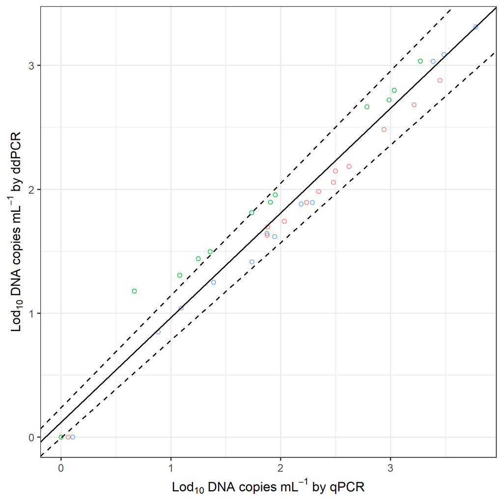

```r
Doi$log10qPCR<-log10(Doi$qCopyNumber+1)
```

```r
Doi$log10dPCR<-log10(Doi$dCopyNumber+1)
```

Now we can plot the initial qPCR versus ddPCR plot to see if we have anything interesting

```r
ggplot(data=Doi,aes(x=log10qPCR,y=log10dPCR))+
  geom_point()
```

To add the line we need to do a bit of stat work to calculate the fitted line and confidence intervals

A type II regression is appropriate when the x and y variables are both random (neither is controlled by the researcher)

Since the quantities are independent of each other (one does not relate directly to the other) a type II was used.

We run the model and save the results to a variable, here called mod1

```r
mod1<-lmodel2(data=Doi,formula=log10dPCR~log10qPCR,nperm=1000)
```

Now we can isolate the data from the model to get the slopes and intercepts for the lines we want to draw

```r
#confidence intervals
CIlines<-mod1$confidence.intervals

#fitted line
Fitline<-mod1$regression.results
```

we only want to plot the major axis calculations - so a bit of indexing to isolate the values below

ggplot works in layers

We start with the initial line which tells the base function where the data set is (data) and we can tell it what axes we want to have constant for all layers (unless we want to change them) using aes (x and y variables)

```r
ggplot(data=Doi,aes(x=log10qPCR,y=log10dPCR))
```

You can then add ‘layers’ to the ggplot image by adding (+) them. Here we add points (geom_point), which follows the base x and y variables

We also add lines, where we stipulate a different set of data and aes variables

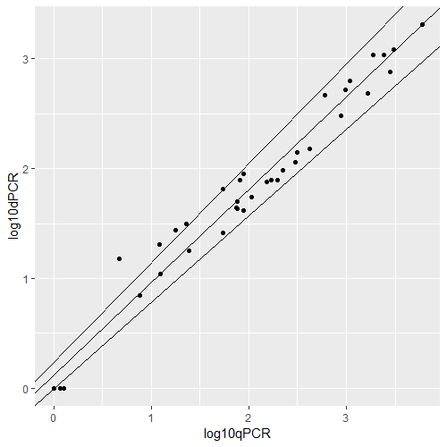

```r
ggplot(data=Doi,aes(x=log10qPCR,y=log10dPCR))+
  geom_point()+
  geom_abline(data=CIlines[CIlines$Method=="MA",],aes(slope=`2.5%-Slope`,intercept=`2.5%-Intercept`))+
  geom_abline(data=CIlines[CIlines$Method=="MA",],aes(slope=`97.5%-Slope`,intercept=`97.5%-Intercept`))+
  geom_abline(data=Fitline[Fitline$Method=="MA",],aes(slope=Slope,intercept=Intercept))
```

Well this looks pretty close - lets clean it up a bit

1. make the points open circles and colored differently for each day

See http://www.cookbook-r.com/Graphs/Shapes_and_line_types/

We have to set the variable Day as a factor here to ensure each unique day is assigned only one color

[figure not shown]

```r
ggplot(data=Doi,aes(x=log10qPCR,y=log10dPCR))+
  geom_point(aes(colour=factor(Day)),shape=1)+
  geom_abline(data=CIlines[CIlines$Method=="MA",],aes(slope=`2.5%-Slope`,intercept=`2.5%-Intercept`))+
  geom_abline(data=CIlines[CIlines$Method=="MA",],aes(slope=`97.5%-Slope`,intercept=`97.5%-Intercept`))+
  geom_abline(data=Fitline[Fitline$Method=="MA",],aes(slope=Slope,intercept=Intercept))
```

2. set the line types of the confidence intervals to dashed lines

see http://www.cookbook-r.com/Graphs/Shapes_and_line_types/

[figure not shown]

```r
ggplot(data=Doi,aes(x=log10qPCR,y=log10dPCR))+
  geom_point(aes(colour=factor(Day)),shape=1)+
  geom_abline(data=CIlines[CIlines$Method=="MA",],aes(slope=`2.5%-Slope`,intercept=`2.5%-Intercept`),linetype="dashed")+
  geom_abline(data=CIlines[CIlines$Method=="MA",],aes(slope=`97.5%-Slope`,intercept=`97.5%-Intercept`),linetype="dashed")+
  geom_abline(data=Fitline[Fitline$Method=="MA",],aes(slope=Slope,intercept=Intercept))
```

to include under and upper scripts we can use bquote - it is a bit complex but I attempt to explain simplistically here (i make no claim to be a full expert)

Use ~ to indicate when the script change is starting or ending Use * to indicate when the combined text is starting or ending Using double ’ to combine the entire quote

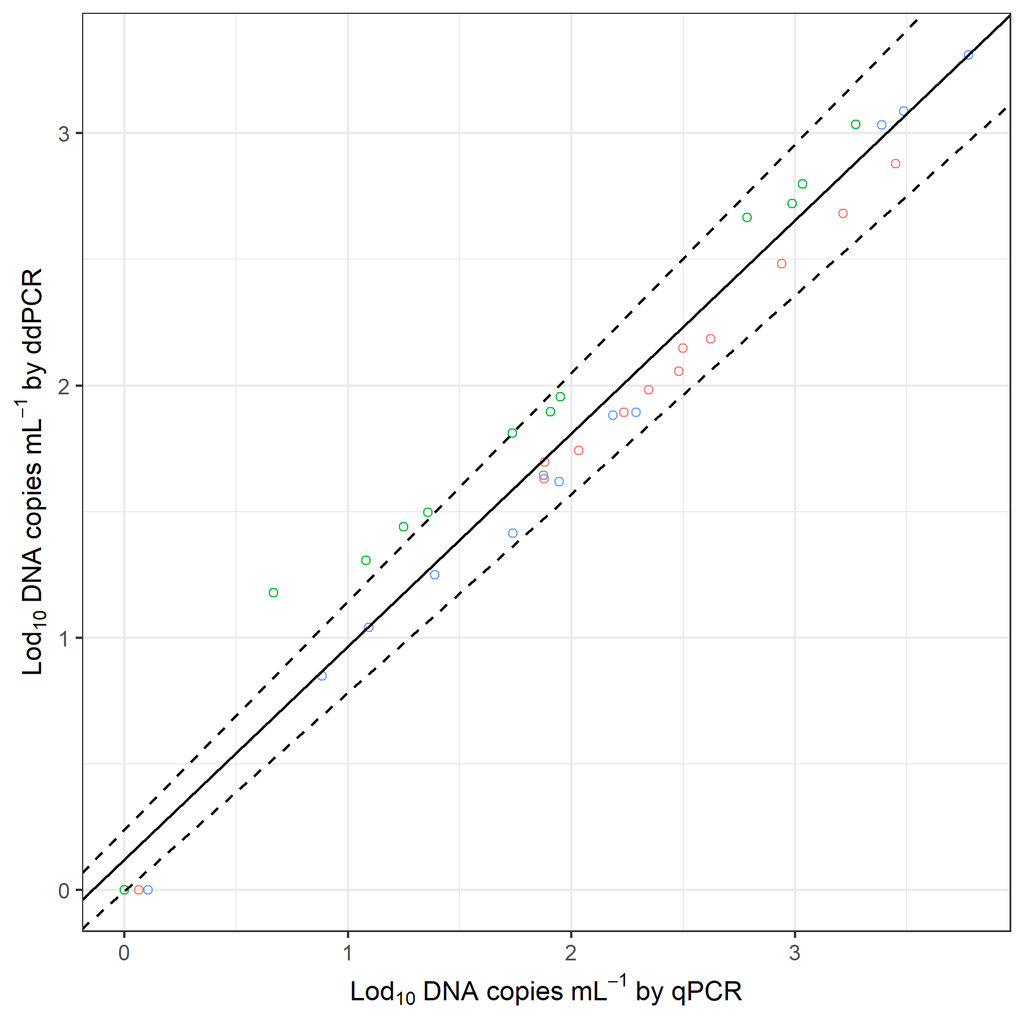

```r
ggplot(data=Doi,aes(x=log10qPCR,y=log10dPCR))+
  theme_bw()+
  theme(legend.position="none")+
  geom_point(aes(colour=factor(Day)),shape=1)+
  geom_abline(data=CIlines[CIlines$Method=="MA",],aes(slope=`2.5%-Slope`,intercept=`2.5%-Intercept`),linetype="dashed")+
  geom_abline(data=CIlines[CIlines$Method=="MA",],aes(slope=`97.5%-Slope`,intercept=`97.5%-Intercept`),linetype="dashed")+
  geom_abline(data=Fitline[Fitline$Method=="MA",],aes(slope=Slope,intercept=Intercept))+
  xlab(bquote(''*Lod[10]~ 'DNA copies' ~mL^-1~ 'by qPCR'*''))+
  ylab(bquote(''*Lod[10]~ 'DNA copies' ~mL^-1~ 'by ddPCR' *''))
```

export the figure high quality (300 dpi)

```r
#vector based (e.g. pdf - Springer journals like these)
ggsave("DoiFigure1.pdf",dpi=300,height=15,width=15,units="cm")
```

```r
#pixel based (e.g. tiff - Wiley journals like these)
ggsave("DoiFigure1.tiff",dpi=300,height=15,width=15,units="cm")
```

now try and recreate one of the figure panel plots for Figure 4.

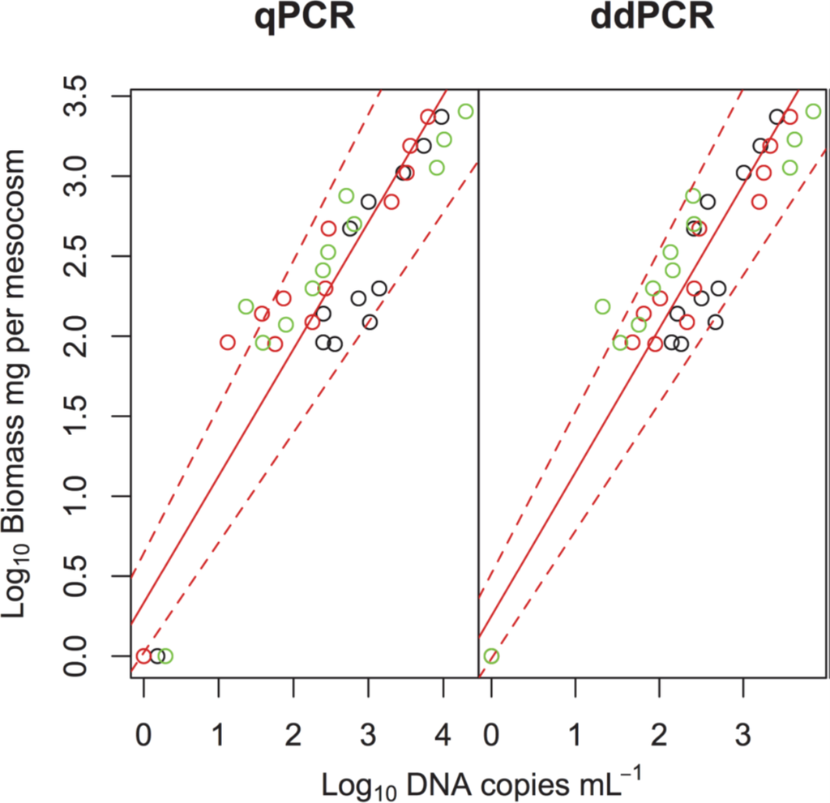

References: Legendre, P. and Legendre, L.F., 2012. Numerical ecology (Vol. 24). Elsevier.